# Настройка NAT в Cisco Packet Tracer

Лабораторная работа №12

Гафоров Нурмухаммад

Российский университет дружбы народов, Москва, Россия

27.04.2026

# Цель работы

## Цель

Приобретение практических навыков  
по настройке NAT и ограничению доступа  
в локальной сети.

# Ход выполнения

## Настройка маршрутизатора провайдера

- Включены интерфейсы (**no shutdown**)
- Настроен подинтерфейс:
  - **Fa0/0.4**
  - VLAN 4 (dot1Q)
- IP:
  - 198.51.100.1 /28
- Внешний интерфейс:
  - 192.0.2.1 /24

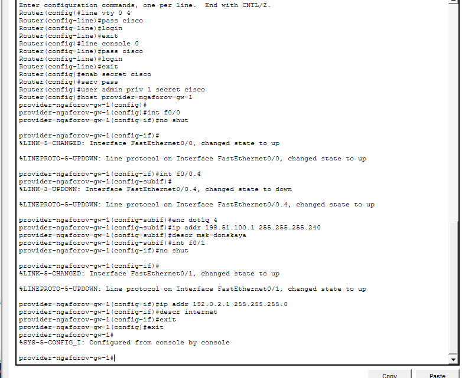

Настройка provider-gw-1

## Настройка коммутатора

- Порты переведены в режим **trunk**
- Создана VLAN 4 (**nat**)
- Настроен интерфейс **Vlan4**

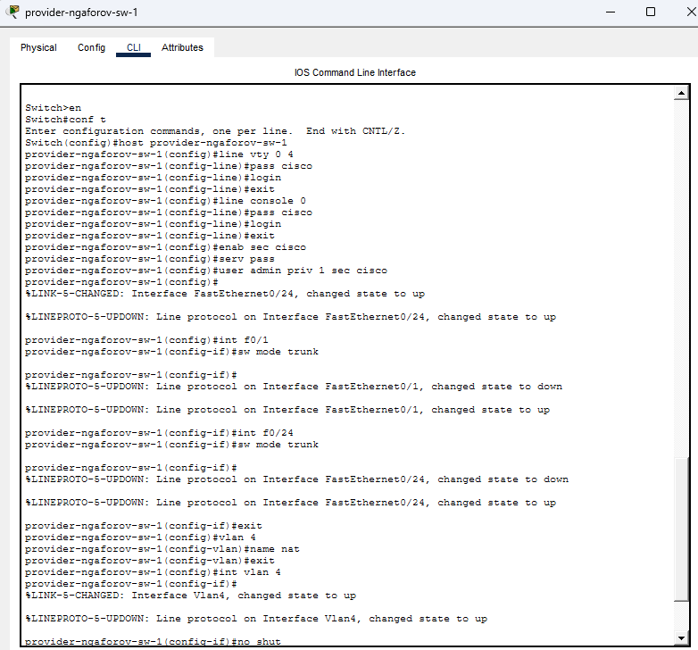

Настройка provider-sw-1

## Подключение сети «Донская»

- Настроен интерфейс:
  - **Fa0/1.4**
- IP:
  - 198.51.100.2 /28
- Добавлен маршрут по умолчанию:
  - 0.0.0.0 → 198.51.100.1

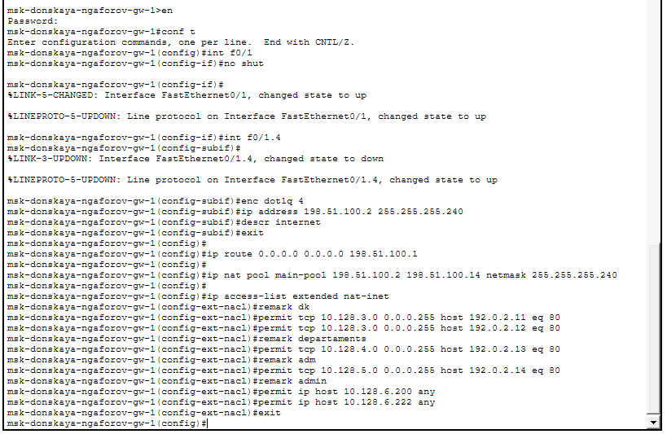

Подключение к провайдеру

## Настройка NAT

- Создан пул:
  - 198.51.100.2–198.51.100.14
- Настроен ACL
- Включён PAT (overload)

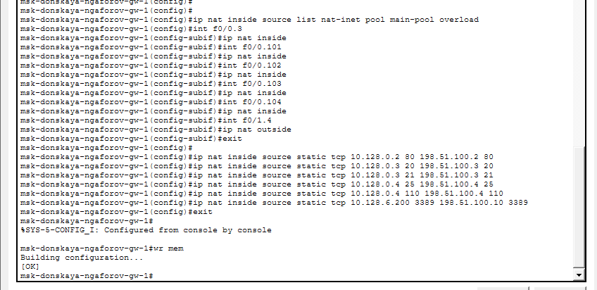

Настройка NAT

## Статический NAT

Настроен проброс портов:

- HTTP → 10.128.0.2
- FTP → 10.128.0.3
- SMTP/POP3 → 10.128.0.4
- RDP → 10.128.6.200

[figure not shown]

# Проверка доступа

## Дисплейные классы

Разрешено:

- www.yandex.ru
- stud.rudn.university

Запрещено:

- другие сайты (Request Timeout)

## Сеть кафедр

Разрешено:

- esystem.pfur.ru

Запрещено:

- остальные сайты

## Сеть администрации

Разрешено:

- www.rudn.ru

Запрещено:

- остальные сайты

## Прочие пользователи

- Администратор → полный доступ
- Остальные → нет доступа в Интернет

# Проверка серверов

## WEB-сервер

- Доступ по HTTP (порт 80)
- Адрес: 198.51.100.2

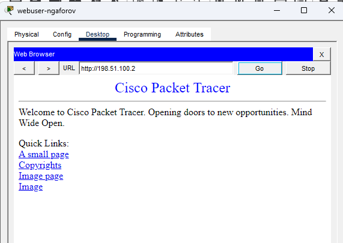

WEB доступ

## FTP-сервер

- Порты: 20 и 21
- Успешное подключение

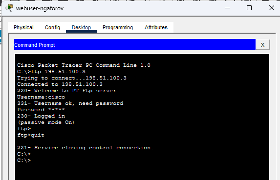

FTP доступ

## Почтовый сервер

- Порты: 25 и 110
- Отправка и получение писем

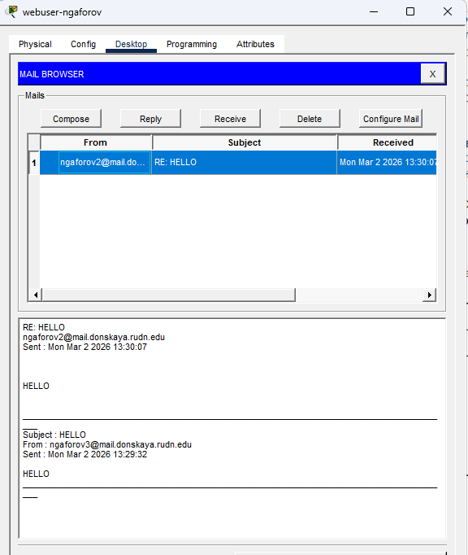

Mail доступ

# Итог

## Вывод

- Настроен NAT (PAT + статический)
- Ограничен доступ пользователей
- Реализован контроль доступа
- Опубликованы внутренние сервисы
- Проверена корректная работа сети